# Assignment7

Ruinan Wang

17/11/2021

## Student’s t-confidence intervals

```r
adelie_flippers <- penguins %>% filter(species=="Adelie") %>% pull(flipper_length_mm) %>% na.omit()
alpha<-0.05
sample_size<-length(adelie_flippers)
sample_mean<-mean(adelie_flippers)
sample_sd<-sd(adelie_flippers)
t<-qt(1-alpha/2,df=sample_size-1)
confidence_interval_l<-sample_mean-t*sample_sd/sqrt(sample_size)
confidence_interval_u<-sample_mean+t*sample_sd/sqrt(sample_size)
confidence_interval<-c(confidence_interval_l,confidence_interval_u)
confidence_interval
```

```
## [1] 188.9021 191.0052
```

```r
data("Hawks")
head(Hawks)
```

```
##   Month Day Year CaptureTime ReleaseTime  BandNumber Species Age Sex Wing
## 1     9  19 1992       13:30               877-76317      RT   I      385
## 2     9  22 1992       10:30               877-76318      RT   I      376
## 3     9  23 1992       12:45               877-76319      RT   I      381
## 4     9  23 1992       10:50               745-49508      CH   I   F  265
## 5     9  27 1992       11:15              1253-98801      SS   I   F  205
## 6     9  28 1992       11:25             1207-55910       RT   I      412
##   Weight Culmen Hallux Tail StandardTail Tarsus WingPitFat KeelFat Crop
## 1    920   25.7   30.1  219           NA     NA         NA      NA   NA
## 2    930     NA     NA  221           NA     NA         NA      NA   NA
## 3    990   26.7   31.3  235           NA     NA         NA      NA   NA
## 4    470   18.7   23.5  220           NA     NA         NA      NA   NA
## 5    170   12.5   14.3  157           NA     NA         NA      NA   NA
## 6   1090   28.5   32.2  230           NA     NA         NA      NA   NA
```

```r
red_tailed_Hawks_weights <- Hawks %>% filter(Species == "RT") %>% pull(Weight)%>% na.omit()

alpha <- 0.01
sample_size <- length(red_tailed_Hawks_weights)
sample_mean <- mean(red_tailed_Hawks_weights)
sample_sd <- sd(red_tailed_Hawks_weights)

t <- qt(1-alpha/2,df=sample_size-1)
l <- mean(sample_mean-t*sample_sd/sqrt(sample_size))
u <- mean(sample_mean+t*sample_sd/sqrt(sample_size))
confidence_interval <- c(l,u)
confidence_interval
```

```
## [1] 1073.984 1114.877
```

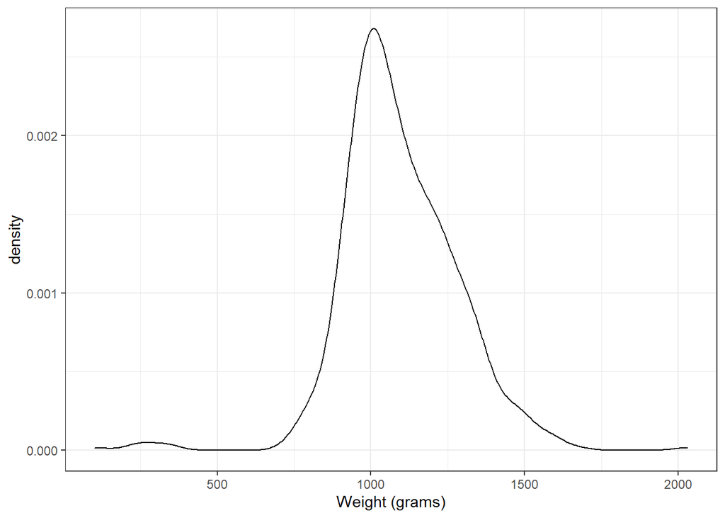

```r
tibble(red_tailed_Hawks_weights) %>% ggplot(aes(x=red_tailed_Hawks_weights))+geom_density()+theme_bw()+labs(x="Weight (grams)", y="density")
```

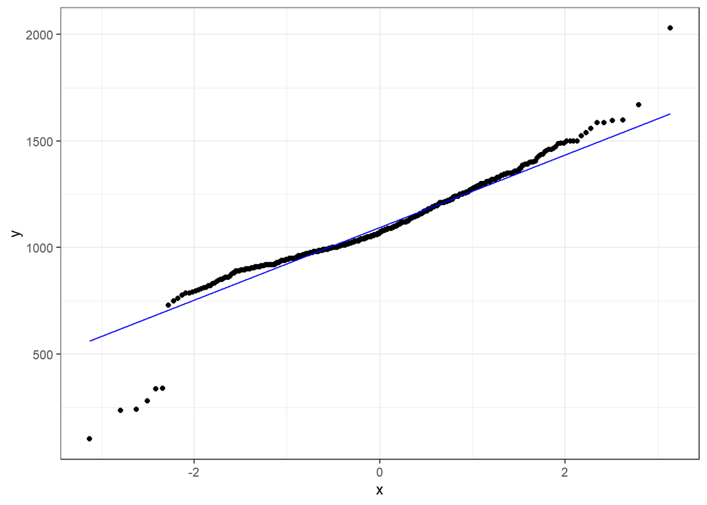

```r
tibble(red_tailed_Hawks_weights) %>% ggplot(aes(sample=red_tailed_Hawks_weights))+stat_qq()+stat_qq_line(color="blue")+theme_bw()
```

##### Before deriving the confidence intervals based on T distribution, we suppose the sample data could be subject to normal distribution

Sample Answer: The Student’s t based confidence intervals for the population mean μ0 were derived based on the assumption that the sample X1,…,Xn ∼ N(μ0,σ20) consists of i.i.d. Gaussian observations. It is also reasonable to apply this method to other i.i.d. samples, provided that the distribution isn’t too heavy tailed and the sample size n is large.

Next we generate a QQ plot. Here we again notice the heavy tails visible within the QQ plot.

## 2 One sample t-test

```r
bill_adelie <- penguins %>% filter(species == "Adelie") %>% pull(bill_length_mm) %>% na.omit()
alpha<- 0.01
sample_size <- length(bill_adelie)
sample_mean <- mean(bill_adelie)
sample_sd <- sd(bill_adelie)
t<-qt(1-alpha/2,df=sample_size-1)
l<-sample_mean-t*sample_sd/sqrt(sample_size)
u<-sample_mean+t*sample_sd/sqrt(sample_size)

confidence_interval <- c(l,u)
confidence_interval
```

```
## [1] 38.22590 39.35688
```

```r
t.test(bill_adelie,conf.level=0.99,mu=40)
```

```
##
##  One Sample t-test
##
## data:  bill_adelie
## t = -5.5762, df = 150, p-value = 1.114e-07
## alternative hypothesis: true mean is not equal to 40
## 99 percent confidence interval:
##  38.22590 39.35688
## sample estimates:
## mean of x
##  38.79139
```

##### (The sample data is supposed to be subject to normal distribution)

Sample Answer: We require that the sample X1,…,Xn and be either Gaussian or have very large sample size n and relatively light tails

## 3 Implementing a one-sample t-test

```r
two_sides_ones_sample_Ttest <- function (X, mu0) {
  sample_mean <- mean(X)
  sample_sd <- sd(X)
  sample_size <- length(X)
  test_statistic <- (sample_mean-mu0)/(sample_sd/sqrt(sample_size))
  p_value <- 2*(1-pt(abs(test_statistic), df=sample_size-1))
  return (p_value)
}
two_sides_ones_sample_Ttest(bill_adelie, 40)
```

```
## [1] 1.114322e-07
```

## 4 The paired t-test

```r
data("Barley")
Glabron_yields <- Barley %>% pull(Glabron) %>% na.omit()
Velvet_yields <- Barley %>% pull(Velvet) %>% na.omit()
t.test(Glabron_yields,Velvet_yields,paired=TRUE,conf.level=0.99)
```

```
##
##  Paired t-test
##
## data:  Glabron_yields and Velvet_yields
## t = 3.0133, df = 11, p-value = 0.0118
## alternative hypothesis: true difference in means is not equal to 0
## 99 percent confidence interval:
##  -0.1816612 12.0149945
## sample estimates:
## mean of the differences
##                5.916667
```

```r
diffs <-  Glabron_yields - Velvet_yields
effect_size <- mean(diffs)/sd(diffs)
effect_size
```

```
## [1] 0.8698615
```

##### one sample value should be subject to normal distribution

Sample Answer: We assume either that the data is i.i.d. Gaussian or i.i.d. with a large sample size

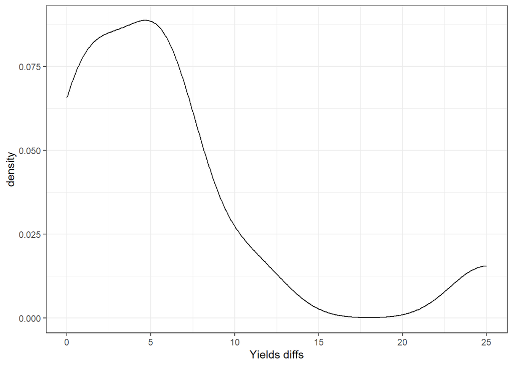

```r
tibble(diffs) %>% ggplot(aes(x=diffs))+geom_density()+theme_bw()+labs(x="Yields diffs", y="density")
```

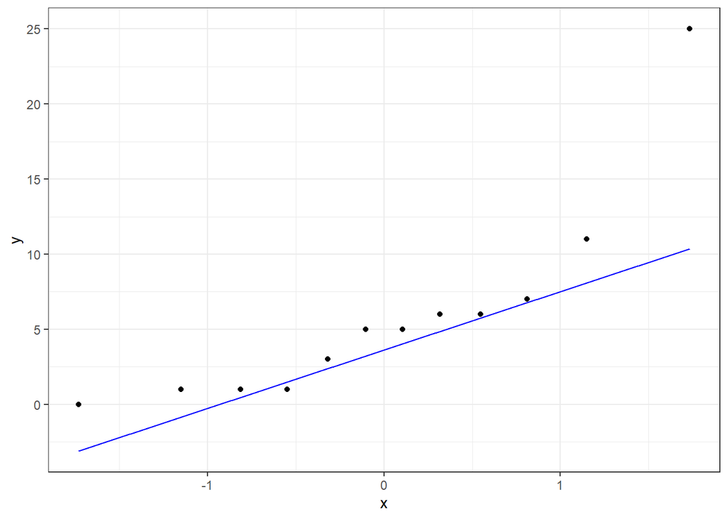

```r
tibble(diffs) %>% ggplot(aes(sample=diffs))+stat_qq()+stat_qq_line(color="blue")+theme_bw()
```

```r
length(diffs)
```

```
## [1] 12
```

this case isn’t subject to normal distribution (Severe skewed distribution). Sample Answer: It seems that the data is approximately Gaussian (although the sample size itself its relatively small). Since the distribution of the data appears approximately Gaussian we are justified in using this approach

### 5 Investing Coverage for Student’s t intervals

```r
student_t_confidence_interval<-function(sample,confidence_level){
  sample<-sample[!is.na(sample)] # remove any missing values
  n<-length(sample) # compute sample size
  mu_est<-mean(sample) # compute sample mean
  sig_est<-sd(sample) # compute sample sd
  alpha = 1-confidence_level # alpha from gamma
  t<-qt(1-alpha/2,df=n-1) # get student t quantile
  l=mu_est-(t/sqrt(n))*sig_est # lower
  u=mu_est+(t/sqrt(n))*sig_est # upper
  return(c(l,u))
}


simulation_study <- function (alpha){
  num_trials<-1000
  sample_size<-30
  mu_0<-1
  sigma_0<-3
  set.seed(0) # set random seed for reproducibility
  single_alpha_coverage_simulation_df<-data.frame(trial=seq(num_trials))%>%
    mutate(sample=map(.x=trial,.f=~rnorm(n=sample_size,mean=mu_0,sd=sigma_0)))%>% # generate random Gaussian samples
    mutate(ci_interval=map(.x=sample,.f=~student_t_confidence_interval(.x,1-alpha)))%>% # generate confidence intervals
    mutate(cover=map_lgl(.x=ci_interval,.f=~((min(.x)<=mu_0)&(max(.x)>=mu_0))))%>% # check if interval covers mu_0
    mutate(ci_length=map_dbl(.x=ci_interval,.f=~(max(.x)-min(.x)))) # compute interval length
  mean_ci_prob <- single_alpha_coverage_simulation_df%>%pull(cover)%>%mean() # estimate of coverage probability
  mean_ci_length <- single_alpha_coverage_simulation_df%>%pull(ci_length)%>%mean()
  return (c(mean_ci_prob,mean_ci_length))
}

alpha_max <- 0.99
simulation_df <- data.frame(alpha=seq(from=0.01,to=1,by=0.01)) %>%
  mutate(gamma=1-alpha)%>%
  mutate(mean_ci_prob = map(.x=alpha,.f= ~simulation_study(.x)[1]), mean_ci_length=map(.x=alpha,.f= ~simulation_study(.x)[2]))
head(simulation_df)
```

```
##   alpha gamma mean_ci_prob mean_ci_length
## 1  0.01  0.99        0.992       3.007381
## 2  0.02  0.98        0.986       2.686212
## 3  0.03  0.97        0.981       2.489988
## 4  0.04  0.96        0.973       2.346133
## 5  0.05  0.95        0.965       2.231467
## 6  0.06  0.94        0.961       2.135523
```

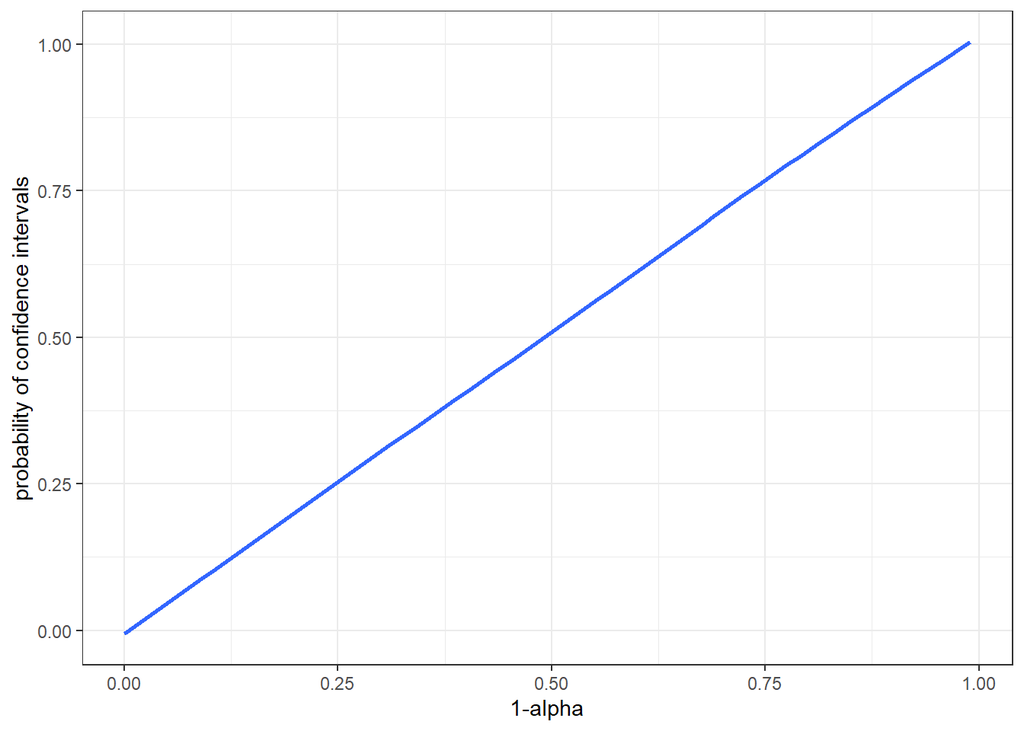

```r
simulation_df$mean_ci_prob=as.numeric(simulation_df$mean_ci_prob)
simulation_df$mean_ci_length=as.numeric(simulation_df$mean_ci_length)

simulation_df %>% ggplot()+geom_smooth(aes(x=gamma, y=mean_ci_prob))+theme_bw()+labs(x="1-alpha", y="probability of confidence intervals")
```

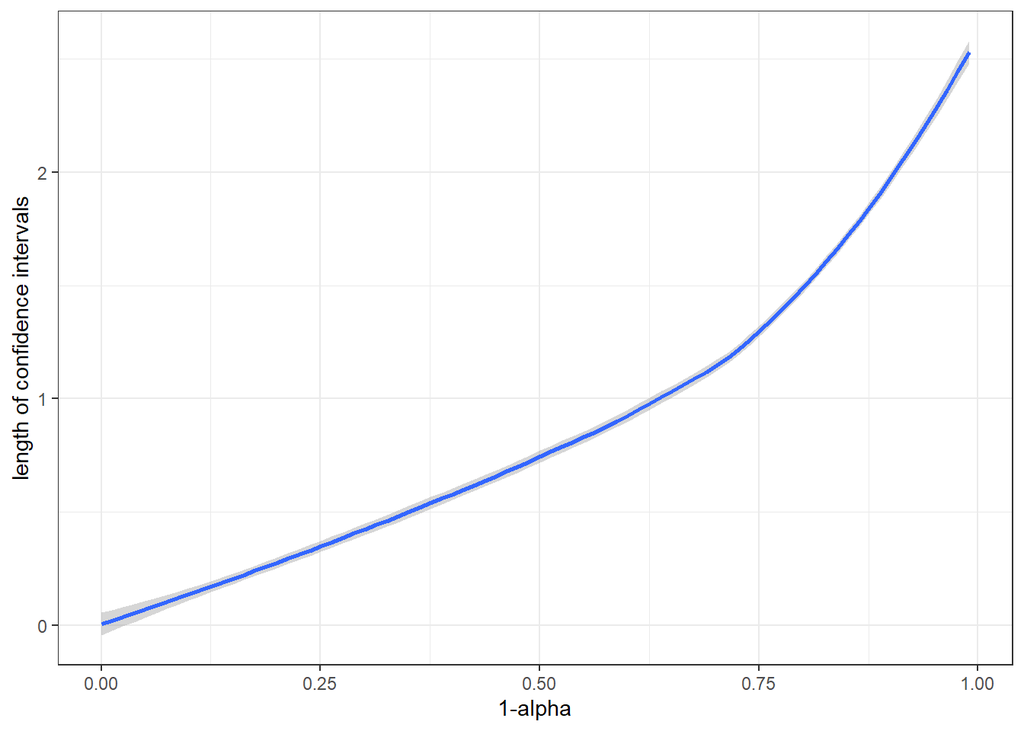

```r
simulation_df %>% ggplot()+geom_smooth(aes(x=gamma, y=round(mean_ci_length,4)))+theme_bw()+labs(x="1-alpha", y="length of confidence intervals")
```

### 6 (Optional) Wilson’s confidence interval for proportions

```r
RT_Weight<- Hawks %>% filter(Species=="RT")%>% pull(Weight) %>% na.omit()
alpha <- 0.05
num_over_one_Kilo <- length(which(RT_Weight>1000))
sample_size<-length(RT_Weight)
scoreci(x=num_over_one_Kilo, n=sample_size, conf.level=1-alpha)
```

```
##
##
##
## data:
##
## 95 percent confidence interval:
##  0.6372 0.7136
```

### 7 (Optional) The Binomial test

```r
library(Stat2Data)
data("Airlines")
Arrivals_Delta_ORD_Result<- Airlines %>%
  subset(airline=="Delta"& airport=="ORD",select=OnTime)

num_onTime <- length(which(Arrivals_Delta_ORD_Result$OnTime=="yes"))
sample_size <- length(Arrivals_Delta_ORD_Result$OnTime)
alpha<- 0.01
binom.test(num_onTime,sample_size,p=0.875,conf.level=1-alpha)
```

```
##
##  Exact binomial test
##
## data:  num_onTime and sample_size
## number of successes = 527, number of trials = 619, p-value = 0.07796
## alternative hypothesis: true probability of success is not equal to 0.875
## 99 percent confidence interval:
##  0.8110315 0.8861753
## sample estimates:
## probability of success
##              0.8513732
```

the sample value (the probability of airlines arrives on time in each sample set) are subject to normal distribution and n*p>5

### 8 (Optional) Bootstrap confidence intervals

```r
library(boot) # load the library
set.seed(123) # set random seed
#first define a function which computes the mean of a column of interest
compute_mean<-function(df,indicies,col_name){
  sub_sample<-df%>%slice(indicies)%>%pull(all_of(col_name)) # extract sub sample
  return(mean(sub_sample,na.rm=1))}# return mean
# use the boot function to generate the bootstrap statistics
results<-boot(data = penguins,statistic =compute_mean,col_name="body_mass_g",R = 1000)
# compute the 95%-level confidence interval for the mean
boot.ci(boot.out = results, type = "basic",conf=0.95)
```

```
## BOOTSTRAP CONFIDENCE INTERVAL CALCULATIONS
## Based on 1000 bootstrap replicates
##
## CALL :
## boot.ci(boot.out = results, conf = 0.95, type = "basic")
##
## Intervals :
## Level      Basic
## 95%   (4112, 4283 )
## Calculations and Intervals on Original Scale
```

The random seed is for reproducibility. The bootstrap approach assumes the data is generated independently and identically distributed from some distribution.

```r
set.seed(123)
compute_median<- function(df,indicies,col_name){
  sub_sample<-df%>%slice(indicies)%>%pull(all_of(col_name))
  return(median(sub_sample,na.rm=1))
}
result<-boot(data = Hawks, statistic = compute_median, col_name="Weight", R=1000)
boot.ci(boot.out = result, type = "basic",conf=0.99)
```

```
## BOOTSTRAP CONFIDENCE INTERVAL CALCULATIONS
## Based on 1000 bootstrap replicates
##
## CALL :
## boot.ci(boot.out = result, conf = 0.99, type = "basic")
##
## Intervals :
## Level      Basic
## 99%   ( 950, 1000 )
## Calculations and Intervals on Original Scale
## Some basic intervals may be unstable
```

```r
set.seed(123)
result_penguins<-boot(data = penguins, statistic = compute_mean, col_name="body_mass_g", R=1000)
boot.ci(boot.out = result_penguins, type = "basic",conf=0.99)
```

```
## BOOTSTRAP CONFIDENCE INTERVAL CALCULATIONS
## Based on 1000 bootstrap replicates
##
## CALL :
## boot.ci(boot.out = result_penguins, conf = 0.99, type = "basic")
##
## Intervals :
## Level      Basic
## 99%   (4091, 4321 )
## Calculations and Intervals on Original Scale
## Some basic intervals may be unstable
```

```r
result_hawks<-boot(data = Hawks, statistic = compute_mean, col_name="Weight", R=1000)
boot.ci(boot.out = result_hawks, type = "basic",conf=0.99)
```

```
## BOOTSTRAP CONFIDENCE INTERVAL CALCULATIONS
## Based on 1000 bootstrap replicates
##
## CALL :
## boot.ci(boot.out = result_hawks, conf = 0.99, type = "basic")
##
## Intervals :
## Level      Basic
## 99%   (735.4, 809.3 )
## Calculations and Intervals on Original Scale
## Some basic intervals may be unstable
```

Assuming these samples are representative, given that the confidence do not intersect and the interval for Hawks is below that for penguins, we have good evidence that the average Hawk weight is below the average penguin weight

### 9 (Optional) Investigating the failure probability for Wilson’s method

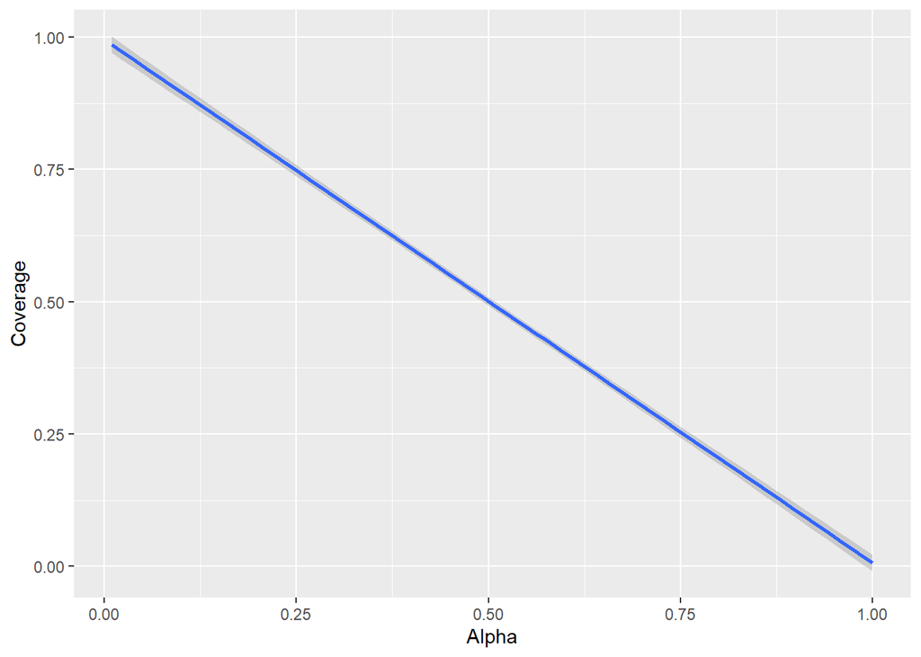

```r
n <- 100
q <-0.5
num_trials_per_alpha <- 1000
alpha <- 0.01
simulation_studys <- crossing(trial=seq(num_trials_per_alpha),alpha=seq(alpha,1,0.01))%>%
  mutate(sample = pmap(.l=list(trial,alpha), .f=~ rbinom(n,1,0.5)))%>%
  mutate(wilson_cf = pmap(.l=list(sample,alpha), .f= ~ unlist(scoreci(sum(.x), n, 1-.y))))%>%
  mutate(cf_l=map_dbl(wilson_cf,min),cf_u=map_dbl(wilson_cf,max))%>%
  mutate(coverage = as.integer(cf_l <= q&cf_u >= q))%>%
  ##mutate(cf_miss=as.integer(cf_l>q|cf_u<q))%>%
  group_by(alpha)%>%
  ##summarise(cf_miss = mean(cf_miss))
  summarise(coverage_mean = mean(coverage))
simulation_studys%>%ggplot(aes(x=alpha,y=coverage_mean))+geom_smooth(method="lm")+ labs(x="Alpha",y="Coverage")
```

### 10 (Optional) Effect size for the one sample t-test

```r
bill_adelie<-penguins%>%
filter(species=="Adelie")%>%
pull(bill_length_mm)%>%
na.omit()

effect_size_one_sample_t_test <- function (X, mu){
  return( (mean(X)-mu)/sd(X))
}
effect_size_one_sample_t_test(bill_adelie,40)
```

```
## [1] -0.4537835
```

medium effect

### 11 (Optional) Confidence intervals for the exponential distribution

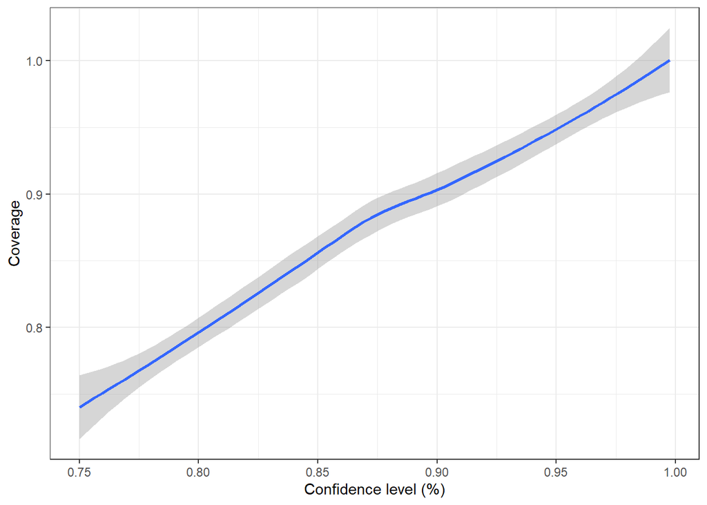

```r
exp_confidence_interval<-function(Sample,confidence_level){
  sample_mean<-mean(Sample)
  alpha <- 1-confidence_level
  Z_alpha <- qnorm(1-alpha/2)
  Ci_l <- 1/sample_mean *(1-Z_alpha/sqrt(length(Sample)))
  ci_u<- 1/sample_mean *(1+Z_alpha/sqrt(length(Sample)))
  return(c(Ci_l,ci_u))
}

num_trials_per_alpha<-100
sample_size<-100
lambda_0<-5
alpha_min<-0.0025
alpha_max<-0.25
alpha_inc<-0.0025
set.seed(0) # set random seed for reproducibility
coverage_simulation_exp_cis_df<-crossing(trial=seq(num_trials_per_alpha),alpha=seq(alpha_min,alpha_max,alpha_inc))%>%
  mutate(sample=map(.x=trial,.f=~rexp(n=sample_size,rate=lambda_0)))%>%
  mutate(gamma=1-alpha)%>% # generate random exponential
  mutate(ci_interval=map2(.x=sample,.y=gamma,.f=~exp_confidence_interval(.x,.y)))%>% # generate confidence intervals
  mutate(cover=map_lgl(.x=ci_interval, .f=~((min(.x)<=lambda_0)&(max(.x)>=lambda_0))))%>% # check if interval covers mu_0
  mutate(ci_length=map_dbl(.x=ci_interval,.f=~(max(.x)-min(.x))))%>% # compute interval length
  group_by(gamma)%>%
  summarise(coverage=mean(cover),mean_length=mean(ci_length))
coverage_simulation_exp_cis_df%>%
  ggplot(aes(x=gamma,y=coverage))+geom_smooth()+xlab("Confidence level (%)")+ylab("Coverage")+theme_bw()
```